# Question

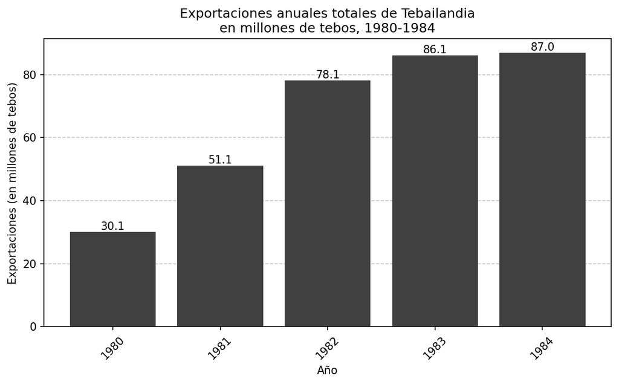

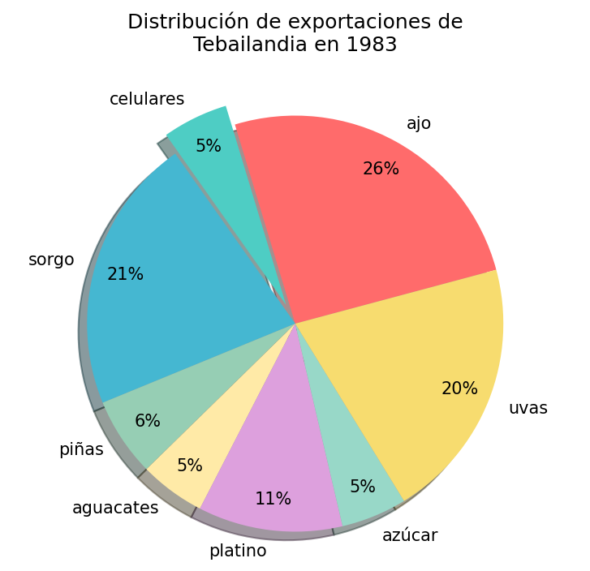

La imagen muestra dos gráficos relacionados con las exportaciones de Tebailandia, un país que usa “tebos” como su moneda.

Para determinar el valor específico de celulares exportado desde Tebailandia en 1983, resuelva paso a paso combinando información de ambos gráficos:

**IMPORTANTE - Formato de números:**

- **Valores monetarios**: Sin separador de miles, use punto para decimales
  - Ejemplo: 16850.32 (no 16.850,32 ni 16850,32)
- **Respuestas numéricas**: Sin separador de miles, use punto para decimales
  - Ejemplo: 1234.5678 (no 1.234,5678 ni 1234,5678)

### Paso 1: Lectura del gráfico de barras

Observe el primer gráfico. ¿Cuál fue el valor total de exportaciones de Tebailandia en 1983?

**Respuesta:** ##ANSWER1## millones de tebos

### Paso 2: Lectura del gráfico circular

Observe el segundo gráfico. ¿Qué porcentaje del total de exportaciones corresponde a celulares en 1983?

**Respuesta:** ##ANSWER2##%

### Paso 3: Configuración de la fórmula

Para calcular el valor de celulares, identifique los componentes de la fórmula:

Valor de celulares = Valor total × (porcentaje del Paso 2 ÷ 100)

Confirme el valor total a usar: ##ANSWER3## millones de tebos

### Paso 4: Configuración de la fórmula (denominador)

Convierta el porcentaje a forma decimal (divida entre 100):

Porcentaje del Paso 2 ÷ 100 = ##ANSWER4##

### Paso 5: Cálculo intermedio

Complete la multiplicación:

Valor del Paso 3 × valor decimal del Paso 4 = ##ANSWER5##

### Paso 6: Resultado final

Por lo tanto, el valor de celulares exportado en 1983 es:

**Respuesta:** ##ANSWER6## millones de tebos

### Paso 7: Confirmación del procedimiento (CON PUNTUACIÓN)

Seleccione el procedimiento correcto para determinar el valor de un producto específico a partir de gráficos estadísticos:

##ANSWER7##

## Answerlist

- Dividir el porcentaje de celulares entre el valor total de exportaciones de 1983.
- Sumar el valor total de exportaciones de 1983 con el porcentaje de celulares.
- Multiplicar el porcentaje de celulares por 100 y dividir entre el valor total de exportaciones.
- Multiplicar el valor total de exportaciones de 1983 por el porcentaje de celulares expresado en forma decimal.

# Solution

### Análisis paso a paso del problema de interpretación de gráficos estadísticos

Este problema de **interpretación de gráficos estadísticos** requiere un análisis secuencial que demuestre el proceso de razonamiento matemático aplicado a contextos económicos reales:

**NOTA IMPORTANTE - Formato de números estandarizado:**

- **Valores monetarios**: Sin separador de miles, use punto para decimales
  - Ejemplo: 16850.32 (no 16.850,32 ni 16850,32)
- **Respuestas numéricas**: Sin separador de miles, punto como separador decimal
  - Ejemplo: 1234.5678 (no 1.234,5678 ni 1234,5678)
- **Consistencia**: Mismo formato en enunciado, opciones y respuestas

### Paso 1: Lectura correcta del gráfico de barras ✓

**Respuesta correcta:** 86.1 millones de tebos

**Razonamiento:** La lectura cuidadosa del gráfico de barras muestra que en 1983 las exportaciones totales de Tebailandia fueron exactamente 86.1 millones de tebos.

**Exportaciones anuales registradas:**

- Año 1980: 30.1 millones de tebos
- Año 1981: 51.1 millones de tebos
- Año 1982: 78.1 millones de tebos
- Año 1983: 86.1 millones de tebos ← **AÑO DE LA PREGUNTA**
- Año 1984: 87 millones de tebos

### Paso 2: Lectura correcta del gráfico circular ✓

**Respuesta correcta:** 5%

**Razonamiento:** El gráfico circular muestra que celulares representa exactamente el 5% del total de exportaciones en 1983.

### Paso 3: Configuración correcta de la fórmula (numerador) ✓

**Respuesta correcta:** 86.1

**Razonamiento:** Para calcular el valor de celulares, necesitamos usar el valor total de exportaciones identificado en el Paso 1 como numerador de la fórmula.

### Paso 4: Configuración correcta de la fórmula (denominador) ✓

**Respuesta correcta:** 0.0500

**Razonamiento:** Para convertir el porcentaje a forma decimal, dividimos entre 100: 5% ÷ 100 = 0.0500

### Paso 5: Cálculo intermedio correcto ✓

**Respuesta correcta:** 4.30

**Cálculo completo:** 86.1 × 0.0500 = 4.30

### Paso 6: Resultado final correcto ✓

**Respuesta correcta:** 4.30 millones de tebos

**Verificación del resultado:**

- El resultado (4.30 millones) es menor que el total (86.1 millones), lo cual es lógico ya que representa solo una fracción del total.
- El cálculo es coherente con la fórmula: Valor total × Porcentaje en decimal = Resultado final

### Paso 7: Confirmación del procedimiento correcto ✓ (CON PUNTUACIÓN)

**Opciones presentadas:**

- **A**: Dividir el porcentaje de celulares entre el valor total de exportaciones de 1983.
- **B**: Sumar el valor total de exportaciones de 1983 con el porcentaje de celulares.
- **C**: Multiplicar el porcentaje de celulares por 100 y dividir entre el valor total de exportaciones.
- **D**: Multiplicar el valor total de exportaciones de 1983 por el porcentaje de celulares expresado en forma decimal. ← **RESPUESTA CORRECTA**

**Análisis de la respuesta correcta:**

“Multiplicar el valor total de exportaciones de 1983 por el porcentaje de celulares expresado en forma decimal.”

- Esta opción representa correctamente el procedimiento matemático
- Identifica la necesidad de multiplicar el valor total por el porcentaje en forma decimal
- Es el método matemáticamente correcto para calcular valores específicos a partir de gráficos estadísticos

### Verificación del proceso de razonamiento completo

**Datos del problema:**

- Valor total de exportaciones en 1983: 86.1 millones de tebos
- Porcentaje de celulares: 5%
- Porcentaje en decimal: 0.0500
- Valor final de celulares: 4.30 millones de tebos

**El formato cloze con confirmación garantiza que los estudiantes:**

**Parte Analítica (Pasos 1-6):**

- **Lean correctamente** ambos tipos de gráficos estadísticos
- **Identifiquen valores específicos** de gráficos de barras y circulares
- **Apliquen fórmulas** de porcentajes paso a paso
- **Realicen cálculos** matemáticos precisos sin saltar etapas

**Parte de Confirmación (Paso 7):**

- **Demuestren coherencia** entre su análisis numérico y la comprensión conceptual
- **Identifiquen el procedimiento correcto** entre múltiples opciones
- **Consoliden su aprendizaje** mediante validación de resultados

### Conclusión

El valor de celulares exportado desde Tebailandia en 1983 es de **4.30 millones de tebos**.

Esta respuesta es coherente porque:

- Se basa en datos extraídos correctamente de ambos gráficos
- Aplica correctamente las fórmulas de porcentajes
- Todos los cálculos intermedios son verificables
- El procedimiento seleccionado es matemáticamente correcto

# Meta-information

exname: ExportacionesGraficos-Estadistica-Interpretacion-Cloze-n3-v1 extype: cloze exsolution: 86.1|5|86.1|0.05|4.3|4.3|0001 exclozetype: num|num|num|num|num|num|schoice extol: 0.01|0.01|0.01|0.0001|0.01|0.01|0 exsection: Estadística|Gráficos|Interpretación|Porcentajes|Análisis de datos exextra[Type]: Interpretación exextra[Program]: R+Python exextra[Language]: es exextra[Level]: 3 exextra[Competencia]: Interpretación y representación exextra[Componente]: Pensamiento aleatorio exextra[Contexto]: Social-económico exextra[Dificultad]: Alta